# TALLERES

Grupo J

18 de diciembre de 2021

## INTEGRANTES

Tauma Salvador, Alvaro Cesar 20181160

Echandia Orihuela, Kelly Lidia 20191302

Uriarte Zaga, Aron Salvad0r 20181161

Romero Cuenca, Mary Carmen 20191312

## TALLER 1

El archivo seguro.csv contiene datos referidos a pólizas de seguros adquiridas por 200 personas, de las cuales se registran los siguientes atributos:

- age: Edad de la persona
- sex: Sexo de la persona
- bmi: Índice de masa corporal
- children: Número de hijos menores de 12 años
- smoker: Indicador de hábito de fumar (0: No, 1: Sí)
- region: Región de residencia de la persona
- charges: Monto mensual que paga, en dólares

### Lectura de datos:

```r
datos <- read.csv("Taller1/seguro.csv",sep = ";")
head(datos)
```

```
##   age    sex    bmi children smoker    region charges
## 1  19 female 27.900        0    yes southwest    7.59
## 2  18   male 33.770        1     no southeast   20.89
## 3  28   male 33.000        3     no southeast   18.53
## 4  33   male 22.705        0     no northwest    3.33
## 5  32   male 28.880        0     no northwest   12.64
## 6  31 female 25.740        0     no southeast    9.76
```

```r
str(datos)
```

```
## 'data.frame':    200 obs. of  7 variables:
##  $ age     : int  19 18 28 33 32 31 46 37 37 60 ...
##  $ sex     : chr  "female" "male" "male" "male" ...
##  $ bmi     : num  27.9 33.8 33 22.7 28.9 ...
##  $ children: int  0 1 3 0 0 0 1 3 2 0 ...
##  $ smoker  : chr  "yes" "no" "no" "no" ...
##  $ region  : chr  "southwest" "southeast" "southeast" "northwest" ...
##  $ charges : num  7.59 20.89 18.53 3.33 12.64 ...
```

### 1

Ejecute las siguientes tareas de preprocesamiento de datos:

1. Retire la columna region

```r
datos <- datos[-6]
head(datos)
```

```
##   age    sex    bmi children smoker charges
## 1  19 female 27.900        0    yes    7.59
## 2  18   male 33.770        1     no   20.89
## 3  28   male 33.000        3     no   18.53
## 4  33   male 22.705        0     no    3.33
## 5  32   male 28.880        0     no   12.64
## 6  31 female 25.740        0     no    9.76
```

2. Renombre las columnas como edad,sexo, imc, nhijos, fuma, gastos

```r
names(datos) <- c("edad","sexo","imc","nhijos","fuma","gastos")
head(datos)
```

```
##   edad   sexo    imc nhijos fuma gastos
## 1   19 female 27.900      0  yes   7.59
## 2   18   male 33.770      1   no  20.89
## 3   28   male 33.000      3   no  18.53
## 4   33   male 22.705      0   no   3.33
## 5   32   male 28.880      0   no  12.64
## 6   31 female 25.740      0   no   9.76
```

3. Recodifique las categorías de la variable sexo como masculino y femenino, fuma: sí y no

```r
datos$sexo[datos$sexo=="female"] <-"femenino"
datos$sexo[datos$sexo =="male"] <- "masculino"
datos$fuma[datos$fuma=="yes"] <-"si"

head(datos)
```

```
##   edad      sexo    imc nhijos fuma gastos
## 1   19  femenino 27.900      0   si   7.59
## 2   18 masculino 33.770      1   no  20.89
## 3   28 masculino 33.000      3   no  18.53
## 4   33 masculino 22.705      0   no   3.33
## 5   32 masculino 28.880      0   no  12.64
## 6   31  femenino 25.740      0   no   9.76
```

### 2

Obtenga la matriz de correlaciones de las variables cuantitativas y presente un gráfico que permita visualizarla

```r
datos[,c(1,3,4,6)] |> cor()
```

```
##              edad        imc     nhijos     gastos
## edad   1.00000000 0.10037859 0.03553105 0.55979388
## imc    0.10037859 1.00000000 0.04210715 0.25051181
## nhijos 0.03553105 0.04210715 1.00000000 0.07908431
## gastos 0.55979388 0.25051181 0.07908431 1.00000000
```

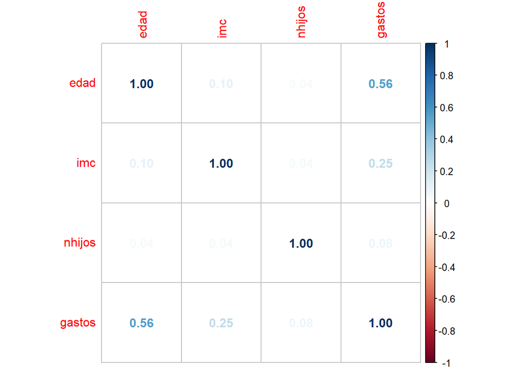

```r
library(corrplot)
datos[,c(1,3,4,6)] |> cor() |> corrplot(method = "number")
```

### 3

Construya un intervalo del 97.5% de confianza para la correlación entre la edad y el imc

```r
attach(datos)
r <- cor(edad,imc)
Zr <- 0.5*log((1+r)/(1-r))
alfa <- 1-0.975
n <- length(edad)
Zr - qnorm(1-alfa/2)*sqrt(1/(n-3)) -> Zrho_inf
Zr + qnorm(1-alfa/2)*sqrt(1/(n-3)) -> Zrho_sup
(exp(2*Zrho_inf)-1)/(exp(2*Zrho_inf)+1) -> rho_inf
(exp(2*Zrho_sup)-1)/(exp(2*Zrho_sup)+1) -> rho_sup
c(rho_inf,rho_sup)
```

```
## [1] -0.05890727  0.25468002
```

```r
cor.test(edad,imc, method = "pearson", alternative = "two.sided", conf.level = 0.975)
```

```
##
##  Pearson's product-moment correlation
##
## data:  edad and imc
## t = 1.4196, df = 198, p-value = 0.1573
## alternative hypothesis: true correlation is not equal to 0
## 97.5 percent confidence interval:
##  -0.05890727  0.25468002
## sample estimates:
##       cor
## 0.1003786
```

### 4

Pruebe si la correlación entre el imc y el número de hijos es significativamente distinta de cero. En caso lo sea, interprete su valor

```r
r <- cor(nhijos,imc)
n <- length(nhijos)
tcalc <- (r*sqrt(n-2)/sqrt(1-r^2))# Cálculo del estadístico-t
```

**Prueba de hipótesis**

Sobre el coeficiente de correlación poblacional (ρ).

H0:ρ=0 ***

H1:ρ≠0

El estadístico de prueba :

$$\displaystyle t_c = \frac{r \sqrt{(n-2)}}{\sqrt{1-r^2}}\\$$
#Hallando el Pvalor

```r
2*pt(abs(tcalc),n-2,lower.tail = FALSE)
```

```
## [1] 0.5538405
```

Intepretacion: No existe evidencia estadistica para afirmar que la correlacion es significativa.

### 5

Se desea estudiar la influencia lineal de la edad sobre los gastos. Presente el modelo de regresión lineal simple estimado.

```r
modelo <- lm(gastos ~ edad)
library(broom)
modelo <- modelo|> tidy()
modelo
```

```
## # A tibble: 2 x 5
##   term        estimate std.error statistic  p.value
##   <chr>          <dbl>     <dbl>     <dbl>    <dbl>
## 1 (Intercept)    3.19     1.21        2.64 8.86e- 3
## 2 edad           0.281    0.0296      9.51 6.85e-18
```

$$y=3.1880837+0.2811175x$$

### 6

Verifique si se cumple la siguiente igualdad

$$\hat{\beta}_1 = \frac{\sum^n_{i=1}(x_i - \overline{x})(y_i - \overline{y})}{\sum^n_{i=1}(x_i - \overline{x})^2} =\frac{Sy}{Sx}R$$

```r
b1 <- modelo$estimate[2];b1
```

```
## [1] 0.2811175
```

```r
b1_ <- (sd(gastos)/sd(edad))*cor(gastos,edad);b1_
```

```
## [1] 0.2811175
```

```r
round(b1)==round(b1_)
```

```
## [1] TRUE
```

### 7

Utilizando las fórmulas de error estándar, construya un intervalo del 92% de confianza para el intercepto y uno de 98% para la pendiente

```r
alfa <- 1-0.92
n <- length(gastos)

#Intervalo de confianza para el beta 0 con un nivel de confianza del 92%
LI <- modelo$estimate[1]-qt(1-alfa/2,n-2)*modelo$std.error[1]
LS <- modelo$estimate[1]+qt(1-alfa/2,n-2)*modelo$std.error[1]
c(LI,LS)
```

```
## [1] 1.065807 5.310361
```

```r
#Intervalo de confianza para el b1 con un nivel de confianza del 98%

alfa <- 1-0.98
n <- length(gastos)

LI <- modelo$estimate[2]-qt(1-alfa/2,n-2)*modelo$std.error[2]
LS <- modelo$estimate[2]+qt(1-alfa/2,n-2)*modelo$std.error[2]
c(LI,LS)
```

```
## [1] 0.2117602 0.3504749
```

```r
#Directamente con R:

library(broom)
modelo <- lm(gastos ~ edad)
##Intervalo de confianza para el b1 y b0  con un nivel de confianza del 92%
modelo|> confint(level = 0.92)
```

```
##                   4 %      96 %
## (Intercept) 1.0658068 5.3103607
## edad        0.2290782 0.3331569
```

```r
##Intervalo de confianza para el b1 y b0  con un nivel de confianza del 98%
modelo|> confint(level = 0.98)
```

```
##                   1 %      99 %
## (Intercept) 0.3595411 6.0166264
## edad        0.2117602 0.3504749
```

### 8

Calcule las sumas de cuadrados para el análisis de varianza

```r
library(broom)
modelo |>  aov()|> summary()
```

```
##              Df Sum Sq Mean Sq F value Pr(>F)
## edad          1   3302    3302   90.36 <2e-16 ***
## Residuals   198   7235      37
## ---
## Signif. codes:  0 '***' 0.001 '**' 0.01 '*' 0.05 '.' 0.1 ' ' 1
```

```r
SCR <- (0.281^2)*var(edad)*(200-1);SCR
```

```
## [1] 3299.098
```

```r
SCT <- var(gastos)*(200-1);SCT
```

```
## [1] 10536.64
```

```r
SCE <- var(gastos)*(200-1)-(0.281^2)*var(edad)*(200-1);SCE
```

```
## [1] 7237.54
```

### 9

Presente el análisis de varianza, redacte sus conclusiones con un nivel de significancia del 5%

H0:β1=0

H1:β1≠0

α=0.05

pvalor = 2e-16

Decisión: Se rechazar la hipótesis nula

Existe suficiente evidencia estadística para indicar que existe una relación lineal de dependencia de los gastos en función a la edad.

### 10

¿A cuánto asciende el valor estimado de σ²? ¿En qué unidades se encuentra establecida esta estimación?

```r
summary(modelo)$sigma**2 # varianza
```

```
## [1] 36.53929
```

### 11

Se desea estudiar la influencia lineal de las variables sobre los gastos. Presente el modelo de regresión lineal múltiple estimado.

```r
modelo2 <- lm(gastos ~ ., data = datos)
modelo2|> tidy()
```

```
## # A tibble: 6 x 5
##   term          estimate std.error statistic  p.value
##   <chr>            <dbl>     <dbl>     <dbl>    <dbl>
## 1 (Intercept)    -5.20      2.50      -2.08  3.88e- 2
## 2 edad            0.269     0.0284     9.47  1.00e-17
## 3 sexomasculino  -0.0894    0.829     -0.108 9.14e- 1
## 4 imc             0.254     0.0727     3.49  5.94e- 4
## 5 nhijos          0.346     0.332      1.04  2.98e- 1
## 6 fumasi          3.27      0.988      3.31  1.11e- 3
```

$$y=-5.19529+0.26917x1-0.08941x2+0.25387137x3+0.34643049x4+3.27114117x5$$

### 12

Interprete los coeficientes de regresión estimados b0 no tiene interpretacion

b1 por cada año de edad que se incremente ,el gasto estimado se incrementa 0.26916527 manteniendo las demas variables en un mismo valor.

b2 para el caso de personas de sexo masculino el gasto promedio es 0.08941 inferior que para el caso del sexo femenino manteniendo las demas variables en un mismo valor

b3 por cada unidad que se incremente el imc ,el gasto estimado se incrementa 0.25387137 manteniendo las demas variables en un mismo valor.

b4 por cada cada nhijo que se incremente ,el gasto estimado se incrementa 0.34643049 manteniendo las demas variables en un mismo valor.

b5 para el caso de personas que si fuman el gasto promedio es 3.27114117 superior que para el caso de personas que no fuman manteniendo las demas variables en un mismo valor.

### 13

```r
#b1  Regreción lineal
modelo <- lm(gastos ~ edad)
modelo <- modelo|> tidy()
modelo$estimate[2]
```

```
## [1] 0.2811175
```

```r
#b1 Regreción lineal multiple

modelo2 <- lm(gastos ~ ., data = datos)
modelo2 <- modelo2|> tidy()
modelo2$estimate[2]
```

```
## [1] 0.2691653
```